# Act Report - Data Wrangling with 'WeRateDogs' Twitter page

## Introduction

The dataset is the tweet archive of Twitter user @dog_rates, also known as WeRateDogs. WeRateDogs is a Twitter account that rates people's dogs with a humorous comment about the dog. These ratings almost always have a denominator of 10. The numerators, though? Almost always greater than 10. 11/10, 12/10, 13/10, etc. Why? Because "they're good dogs Brent." WeRateDogs has over 4 million followers and has received international media coverage.

Real-world data rarely comes clean and usually with multiple data sources. In order to have clear understanding, data wrangling becomes very important.

After data wrangling, I gained three insights from master dataset:

## Insight 1 - Average ratings

From 1288 entries, the average is 12.24, including 22 outliers. Outliers were mostly 14 (hence maybe not really an outlier given the (agreed) max would be 13) but there were certain values larger than even 1,700. This was out of average 8,238 favourite clicks, which IQR is 1,686 to 10,235 with max of 127,573. Given min is 80, can tell a lot of people likes few dog photos - concentration. Having said that, it is not to say there were small number of dog photos versus audiences. The number of dogs names were very high, over 660.

## Insight 2 - Breed that is the most loved

As this is visual reaction by the audiences, the outlook and appearnace of the dogs, is very likely to be one of the biggest decision factor.

The top five breeds that gets most 'likes/favourites' is:

1) Golden Retriever 93;

2) Pembroke 65;

3) Labrador Retriever 59;

4) Chihuahua 45;

5) Pug 39

Having said that, by far, Golden Retriever is an absolute winner (93 vs 65), compared to the 2nd and 3rd (65 vs 59).

## Insight 3

Twitter being SNS, how much attention it receives, is one of the keys to understand how much it is liked. For Twitter, the number of 'favourites' received and number of 'retweeted' is how to measure how much attention it received.

```
Text(0,0.5,'Favourite count')
```

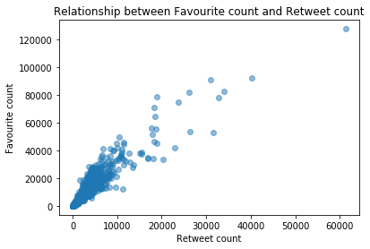

```python
plt.scatter(x=df_master.retweet_count, y=df_master.favorite_count, alpha = 0.5)
plt.title("Relationship between Favourite count and Retweet count")
plt.xlabel("Retweet count")
plt.ylabel("Favourite count")
```

```python
df_master.retweet_count.corr(df_master.favorite_count, method="pearson")
```

```
0.9261796744053018
```

The above shows strong correlation between 'favourite count' and 'retweet count' of circa 0.93. This shows the tendency that if a particular audience liked a photo, he/she is very highligh likely to 'favourite' it and 'retweet' it at the same time.